# 065-253_L01-Andre-Oliveira-de-Carvalho-eSilva

Andre Oliveira de Carvalho e Silva

2025-10-24

# Matriz simples

## Construa a seguinte matriz e denomine ela como minhaMat.

```r
# craindo um vetor para cada linha
linha1<- c(6,112,5,545)
linha2<-c(34,113,9,546)
linha3<-c(923,114,34,547)
linha4<-c(5,115,76,548)
linha5<-c(0,116,2,549)
minhaMat<- rbind(linha1,linha2,linha3,linha4,linha5) # junta por linha
minhaMat
```

```
##        [,1] [,2] [,3] [,4]
## linha1    6  112    5  545
## linha2   34  113    9  546
## linha3  923  114   34  547
## linha4    5  115   76  548
## linha5    0  116    2  549
```

## Obtenha a média de cada linha.

```r
rowMeans(minhaMat)
```

```
## linha1 linha2 linha3 linha4 linha5
## 167.00 175.50 404.50 186.00 166.75
```

## Obtenha a média de cada coluna.

```r
colMeans(minhaMat)
```

```
## [1] 193.6 114.0  25.2 547.0
```

## Ordene as colunas em ordem ascendente

```r
# o sort organiza em forma crescente e já que es
colunaascendente<-apply(minhaMat, 2,sort)
colunaascendente
```

```
##      [,1] [,2] [,3] [,4]
## [1,]    0  112    2  545
## [2,]    5  113    5  546
## [3,]    6  114    9  547
## [4,]   34  115   34  548
## [5,]  923  116   76  549
```

## Use a função apply para executar a operação módulo da divisão por 10 em cada elemento da matriz (A nova matriz contém o resto da divisão por 10).

```r
modolo<-function(x){
  return(x%%10)

  }
matrizModulo10<-apply(minhaMat, 2, modolo)

matrizModulo10
```

```
##        [,1] [,2] [,3] [,4]
## linha1    6    2    5    5
## linha2    4    3    9    6
## linha3    3    4    4    7
## linha4    5    5    6    8
## linha5    0    6    2    9
```

# Conjunto de dados mtcars

## Use três funções da família apply para o obter o mínimo de cada coluna do conjunto de dados. Armazene cada resultado em um objeto separado (l, s e m) e mostre suas saídas.

```r
# lapply aplica certa função a cada coluna do data frame , tratando cada coluna como o elemento de uma lista
l<-lapply(X=mtcars ,FUN=min)
l
```

```
## $mpg
## [1] 10.4
##
## $cyl
## [1] 4
##
## $disp
## [1] 71.1
##
## $hp
## [1] 52
##
## $drat
## [1] 2.76
##
## $wt
## [1] 1.513
##
## $qsec
## [1] 14.5
##
## $vs
## [1] 0
##
## $am
## [1] 0
##
## $gear
## [1] 3
##
## $carb
## [1] 1
```

```r
# sapply é uma versão simplificada do lapply, tenta retornar vetor ou matriz
s<- sapply(X=mtcars,FUN=min)
s
```

```
##    mpg    cyl   disp     hp   drat     wt   qsec     vs     am   gear   carb
## 10.400  4.000 71.100 52.000  2.760  1.513 14.500  0.000  0.000  3.000  1.000
```

```r
# O mapply() trata cada COLUNA como um vetor separado e tenta por padrrão simplificar o resultado
m<- mapply(min,mtcars)
m
```

```
##    mpg    cyl   disp     hp   drat     wt   qsec     vs     am   gear   carb
## 10.400  4.000 71.100 52.000  2.760  1.513 14.500  0.000  0.000  3.000  1.000
```

## Coloque os três objetos l, s e m na lista lista.objetos

```r
lista.objetos<-list(l,s,m)
class(lista.objetos)
```

```
## [1] "list"
```

## Use uma função apply adequada para obter a classe de cada um dos três elementos da lista lista.objetos

```r
 # a função apply é a mais apropiada para usar em uma lista
lapply(X=lista.objetos,FUN=class)
```

```
## [[1]]
## [1] "list"
##
## [[2]]
## [1] "numeric"
##
## [[3]]
## [1] "numeric"
```

## Qual a classe da saída de cada uma das três funções usadas no exercício?

```r
# a função lapply retorna uma lista a função sapply e mapply por padrão tenta "simplificar" retornar um vetor e nesse caso retornou vetores numericos
```

```r
library(microbenchmark)
# Função com apply
com_apply <- function() {
  sapply(mtcars, min)
}

# Função com for loop
com_for <- function() {
  resultado <- numeric(ncol(mtcars))
  for (i in 1:ncol(mtcars)) {
    resultado[i] <- min(mtcars[[i]])
  }
  names(resultado) <- names(mtcars)
  resultado
}

# Comparação detalhada
comparacao <- microbenchmark(
  "Família Apply" = com_apply(),
  "For Loop" = com_for(),
  times = 1000  # Executa 1000 vezes cada
)

print(comparacao)
```

```
## Unit: microseconds
##           expr  min   lq    mean median    uq    max neval
##  Família Apply 16.6 17.4 21.3985   17.8 19.60 1679.1  1000
##       For Loop 38.4 39.6 50.6493   40.3 45.75 4400.0  1000
```

```r
# Resultados
cat("\nMínimo de cada coluna com apply:\n")
```

```
##
## Mínimo de cada coluna com apply:
```

```r
print(com_apply())
```

```
##    mpg    cyl   disp     hp   drat     wt   qsec     vs     am   gear   carb
## 10.400  4.000 71.100 52.000  2.760  1.513 14.500  0.000  0.000  3.000  1.000
```

```r
cat("\nMínimo de cada coluna com for loop:\n")
```

```
##
## Mínimo de cada coluna com for loop:
```

```r
print(com_for())
```

```
##    mpg    cyl   disp     hp   drat     wt   qsec     vs     am   gear   carb
## 10.400  4.000 71.100 52.000  2.760  1.513 14.500  0.000  0.000  3.000  1.000
```

A família apply geralmente é mais rápida que estruturas de controle

A diferença é pequena para datasets pequenos como mtcars

Para datasets maiores, a vantagem da família apply se torna mais significativa

# Função mapply.

## Use a função mapply para obter uma lista de 10 elementos. O primeiro elemento da lista é uma sequência de 10 caracteres “A”; a segunda, 9 caracteres “F”, que seguem alternando-se até o último elemento o qual possui um único caractere.

```r
lista<- list("A", "F")


mapply(FUN=rep,lista, 10:1, SIMPLIFY = FALSE)
```

```
## [[1]]
##  [1] "A" "A" "A" "A" "A" "A" "A" "A" "A" "A"
##
## [[2]]
## [1] "F" "F" "F" "F" "F" "F" "F" "F" "F"
##
## [[3]]
## [1] "A" "A" "A" "A" "A" "A" "A" "A"
##
## [[4]]
## [1] "F" "F" "F" "F" "F" "F" "F"
##
## [[5]]
## [1] "A" "A" "A" "A" "A" "A"
##
## [[6]]
## [1] "F" "F" "F" "F" "F"
##
## [[7]]
## [1] "A" "A" "A" "A"
##
## [[8]]
## [1] "F" "F" "F"
##
## [[9]]
## [1] "A" "A"
##
## [[10]]
## [1] "F"
```

## Ajuste a função para obter a numeração adequada de cada elemento da lista. Dica: argumento USE.NAMES

```r
letras <- rep(c("A", "F"), length.out = 10)
vezes <- 10:1

resultado <- mapply(FUN = rep, letras, vezes,
                    SIMPLIFY = FALSE,
                    USE.NAMES = TRUE)
names(resultado) <- paste0(letras, vezes)

resultado
```

```
## $A10
##  [1] "A" "A" "A" "A" "A" "A" "A" "A" "A" "A"
##
## $F9
## [1] "F" "F" "F" "F" "F" "F" "F" "F" "F"
##
## $A8
## [1] "A" "A" "A" "A" "A" "A" "A" "A"
##
## $F7
## [1] "F" "F" "F" "F" "F" "F" "F"
##
## $A6
## [1] "A" "A" "A" "A" "A" "A"
##
## $F5
## [1] "F" "F" "F" "F" "F"
##
## $A4
## [1] "A" "A" "A" "A"
##
## $F3
## [1] "F" "F" "F"
##
## $A2
## [1] "A" "A"
##
## $F1
## [1] "F"
```

```r
# Criando os vetores de letras e quantidades
letras <- c("A", "F")
tam <- 10:1
letras_alt <- rep(letras, length.out = length(tam))

# Gerando a lista com mapply
tempo_mapply <- system.time({
  lista_mapply <- mapply(FUN = rep,
                         x = letras_alt,
                         times = tam,
                         SIMPLIFY = FALSE,
                         USE.NAMES = TRUE)
})
# usando estrururas de controle
tempo_for <- system.time({
  lista_for <- list()
  for (i in 1:length(tam)) {
    lista_for[[i]] <- rep(letras_alt[i], tam[i])
  }
  names(lista_for) <- paste0("Elemento_", 1:length(tam))
})
#comparando tempo
tempo_mapply
```

```
##   usuário   sistema decorrido
##         0         0         0
```

```r
tempo_for
```

```
##   usuário   sistema decorrido
##         0         0         0
```

# Sobrevivência dos passageiros do Titanic – conjunto de dados Titanic{datasets}:

## Use uma função apply apropriada para obter a soma de homens e mulheres à bordo.

```r
head(Titanic)
```

```
## , , Age = Child, Survived = No
##
##       Sex
## Class  Male Female
##   1st     0      0
##   2nd     0      0
##   3rd    35     17
##   Crew    0      0
##
## , , Age = Adult, Survived = No
##
##       Sex
## Class  Male Female
##   1st   118      4
##   2nd   154     13
##   3rd   387     89
##   Crew  670      3
##
## , , Age = Child, Survived = Yes
##
##       Sex
## Class  Male Female
##   1st     5      1
##   2nd    11     13
##   3rd    13     14
##   Crew    0      0
##
## , , Age = Adult, Survived = Yes
##
##       Sex
## Class  Male Female
##   1st    57    140
##   2nd    14     80
##   3rd    75     76
##   Crew  192     20
```

```r
# apply soma as colunas (no caso male e famale) do Titanic
apply(X=Titanic,2,FUN=sum)
```

```
##   Male Female
##   1731    470
```

# Construa uma tabela com a soma de sobreviventes pela variável Sex.

```r
titanic_df <- as.data.frame(Titanic)

# Soma de frequências por Sexo
tapply(titanic_df$Freq, titanic_df$Sex, sum)
```

```
##   Male Female
##   1731    470
```

```r
# Soma de sobreviventes por Sexo
sobreviventes <- titanic_df[titanic_df$Survived == "Yes", ]
tapply(sobreviventes$Freq, sobreviventes$Sex, sum)
```

```
##   Male Female
##    367    344
```

# Obtenha uma tabela com a quantidade de passageiros pelas variáveis Sex e Age.

```r
# quantidade de passageiros por idade
tapply(titanic_df$Freq,titanic_df$Age,sum)
```

```
## Child Adult
##   109  2092
```

```r
# quantidade de passageiros por sexo
tapply(titanic_df$Freq,titanic_df$Sex,sum)
```

```
##   Male Female
##   1731    470
```

```r
#tabela sexo x idade
tabela_completa<-tapply(titanic_df$Freq,list(titanic_df$Sex,titanic_df$Age),sum)
tabela_completa
```

```
##        Child Adult
## Male      64  1667
## Female    45   425
```

# Repita o exercício usando estruturas de controle. Compare o tempo entre eas duas abordagens (Estruturas de controle e família apply).

```r
# Inicializar contadores
homens <- 0
mulheres <- 0

# Loop através de cada linha do dataframe
for(i in 1:nrow(titanic_df)) {
  if(titanic_df$Sex[i] == "Male") {
    homens <- homens + titanic_df$Freq[i]
  } else {
    mulheres <- mulheres + titanic_df$Freq[i]
  }
}

soma_sexo_loop <- c(Male = homens, Female = mulheres)
print(soma_sexo_loop)
```

```
##   Male Female
##   1731    470
```

```r
# Inicializar contadores
sobreviventes_m <- 0
sobreviventes_f <- 0

for(i in 1:nrow(titanic_df)) {
  if(titanic_df$Survived[i] == "Yes") {
    if(titanic_df$Sex[i] == "Male") {
      sobreviventes_m <- sobreviventes_m + titanic_df$Freq[i]
    } else {
      sobreviventes_f <- sobreviventes_f + titanic_df$Freq[i]
    }
  }
}

sobreviventes_sexo_loop <- c(Male = sobreviventes_m, Female = sobreviventes_f)
print(sobreviventes_sexo_loop)
```

```
##   Male Female
##    367    344
```

```r
# Criar estrutura para armazenar resultados
resultado <- list()

# Combinacoes possíveis
sexos <- unique(titanic_df$Sex)
idades <- unique(titanic_df$Age)

# Inicializar matriz de resultados
matriz_resultado <- matrix(0, nrow = length(sexos), ncol = length(idades))
rownames(matriz_resultado) <- sexos
colnames(matriz_resultado) <- idades

# Loop duplo
for(sexo in sexos) {
  for(idade in idades) {
    total <- 0
    # Loop pelas linhas do dataframe
    for(i in 1:nrow(titanic_df)) {
      if(titanic_df$Sex[i] == sexo & titanic_df$Age[i] == idade) {
        total <- total + titanic_df$Freq[i]
      }
    }
    matriz_resultado[sexo, idade] <- total
  }
}

print(matriz_resultado)
```

```
##        Child Adult
## Male      64  1667
## Female    45   425
```

```r
# Medir tempo das abordagens apply
tempo_apply <- system.time({
  apply(X=Titanic,2,FUN=sum)
  titanic_df <- as.data.frame(Titanic)

# Soma de frequências por Sexo
tapply(titanic_df$Freq, titanic_df$Sex, sum)

# Soma de sobreviventes por Sexo
sobreviventes <- titanic_df[titanic_df$Survived == "Yes", ]
tapply(sobreviventes$Freq, sobreviventes$Sex, sum)
# quantidade de passageiros por idade
tapply(titanic_df$Freq,titanic_df$Age,sum)
# quantidade de passageiros por sexo
tapply(titanic_df$Freq,titanic_df$Sex,sum)
#tabela sexo x idade
tabela_completa<-tapply(titanic_df$Freq,list(titanic_df$Sex,titanic_df$Age),sum)
tabela_completa

})

# Medir tempo das abordagens com loops
tempo_loop <- system.time({
 homens <- 0
mulheres <- 0

# Loop através de cada linha do dataframe
for(i in 1:nrow(titanic_df)) {
  if(titanic_df$Sex[i] == "Male") {
    homens <- homens + titanic_df$Freq[i]
  } else {
    mulheres <- mulheres + titanic_df$Freq[i]
  }
}

soma_sexo_loop <- c(Male = homens, Female = mulheres)
print(soma_sexo_loop)

# Inicializar contadores
sobreviventes_m <- 0
sobreviventes_f <- 0

for(i in 1:nrow(titanic_df)) {
  if(titanic_df$Survived[i] == "Yes") {
    if(titanic_df$Sex[i] == "Male") {
      sobreviventes_m <- sobreviventes_m + titanic_df$Freq[i]
    } else {
      sobreviventes_f <- sobreviventes_f + titanic_df$Freq[i]
    }
  }
}

sobreviventes_sexo_loop <- c(Male = sobreviventes_m, Female = sobreviventes_f)
print(sobreviventes_sexo_loop)

# Criar estrutura para armazenar resultados
resultado <- list()

# Combinacoes possíveis
sexos <- unique(titanic_df$Sex)
idades <- unique(titanic_df$Age)

# Inicializar matriz de resultados
matriz_resultado <- matrix(0, nrow = length(sexos), ncol = length(idades))
rownames(matriz_resultado) <- sexos
colnames(matriz_resultado) <- idades

# Loop duplo
for(sexo in sexos) {
  for(idade in idades) {
    total <- 0
    # Loop pelas linhas do dataframe
    for(i in 1:nrow(titanic_df)) {
      if(titanic_df$Sex[i] == sexo & titanic_df$Age[i] == idade) {
        total <- total + titanic_df$Freq[i]
      }
    }
    matriz_resultado[sexo, idade] <- total
  }
}
})
```

```
##   Male Female
##   1731    470
##   Male Female
##    367    344
```

```r
# Comparar resultados
cat("Tempo com apply:\n")
```

```
## Tempo com apply:
```

```r
print(tempo_apply)
```

```
##   usuário   sistema decorrido
##         0         0         0
```

```r
cat("\nTempo com loops:\n")
```

```
##
## Tempo com loops:
```

```r
print(tempo_loop)
```

```
##   usuário   sistema decorrido
##      0.01      0.00      0.02
```

```r
cat("\nDiferença:", tempo_loop[3] - tempo_apply[3], "segundos\n")
```

```
##
## Diferença: 0.02 segundos
```

# Extração de elementos de uma lista de matrizes, usando lapply:

## Crie uma lista de quatro matrizes e denomine-a lista.obj. Seus elementos são:

```r
primeira <- matrix(38:66, 3)
segunda <- matrix(56:91, 3)
terceira <- matrix(82:145, 3)
quarta <- matrix(46:93, 5)
lista.obj<-list(primeira, segunda, terceira,
quarta)
```

## Extraia a segunda coluna de cada matriz dessa lista de matrizes.

```r
# Primeiro criamos uma função com nome
extrair_segunda_coluna <- function(minha_matriz) {
  return(minha_matriz[, 2])  # Pega todas as linhas da coluna 2
}

# Aí usamos essa função

sapply(X=lista.obj,FUN = extrair_segunda_coluna)
```

```
## [[1]]
## [1] 41 42 43
##
## [[2]]
## [1] 59 60 61
##
## [[3]]
## [1] 85 86 87
##
## [[4]]
## [1] 51 52 53 54 55
```

## Extraia a terceira linha de cada matriz dessa lista de matrizes.

```r
extrair_terceira_linha<-function(minha_matriz)
{
  return(minha_matriz[3,])

}
sapply(X=lista.obj,FUN = extrair_terceira_linha)
```

```
## [[1]]
##  [1] 40 43 46 49 52 55 58 61 64 38
##
## [[2]]
##  [1] 58 61 64 67 70 73 76 79 82 85 88 91
##
## [[3]]
##  [1]  84  87  90  93  96  99 102 105 108 111 114 117 120 123 126 129 132 135 138
## [20] 141 144  83
##
## [[4]]
##  [1] 48 53 58 63 68 73 78 83 88 93
```

## Repita o exercício usando estruturas de controle. Compare o tempo entre as duas abordagens (Estruturas de controle e família apply).

```r
# Extrair terceira linha usando for loop
extrair_terceira_linha_for <- function(lista_matrizes) {
  resultado <- list()

  for (i in 1:length(lista_matrizes)) {
    # i: índice que percorre cada posição da lista
    # lista_matrizes[[i]]: acessa cada matriz individualmente
    resultado[[i]] <- lista_matrizes[[i]][3, ]  # Extrai a terceira linha
  }

  return(resultado)
}

# Executando
resultado_for <- extrair_terceira_linha_for(lista.obj)

# Extrair terceira linha usando sapply
extrair_terceira_linha_apply <- function(matriz) {
  return(matriz[3, ])
}

resultado_apply <- sapply(X = lista.obj, FUN = extrair_terceira_linha_apply)
# Carregar pacote para medição precisa
if (!require(microbenchmark)) install.packages("microbenchmark")
library(microbenchmark)

# Comparar performance
comparacao <- microbenchmark(
  "FOR_LOOP" = {
    resultado <- list()
    for (i in 1:length(lista.obj)) {
      resultado[[i]] <- lista.obj[[i]][3, ]
    }
    resultado
  },
  "FAMILIA_APPLY" = {
    sapply(lista.obj, function(matriz) matriz[3, ])
  },
  times = 1000  # Executa cada método 1000 vezes
)

# Visualizar resultados
print(comparacao)
```

```
## Unit: microseconds
##           expr    min     lq      mean  median      uq    max neval
##       FOR_LOOP 1431.3 1503.6 1715.4074 1548.80 1690.35 6918.9  1000
##  FAMILIA_APPLY   10.6   12.5   22.6852   20.45   24.30 1526.6  1000
```

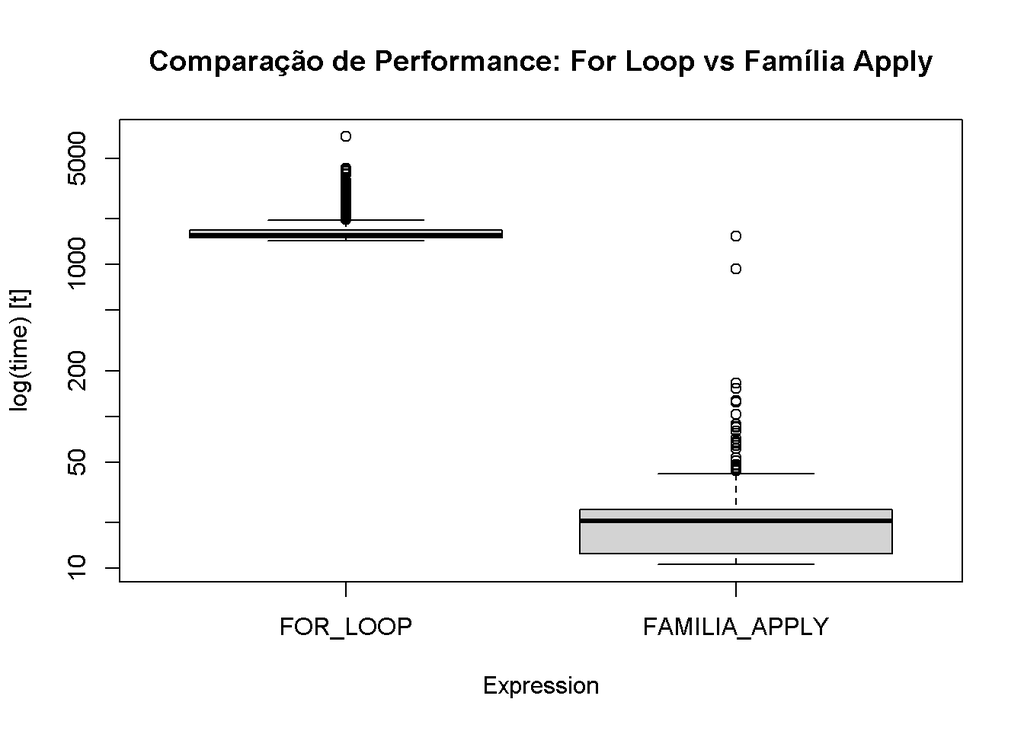

```r
# Boxplot visual
boxplot(comparacao, main = "Comparação de Performance: For Loop vs Família Apply")
```

# Gráficos usando a família apply – conjunto de dados iris{datasets}:

## Obtenha um box-plot de cada variável quantitativa do conjunto de dados, estratificada pela variável Species

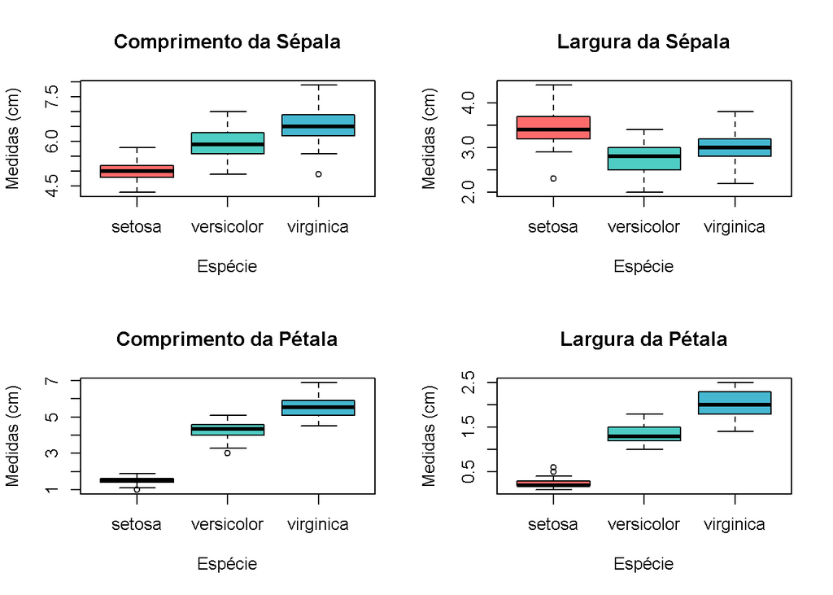

[output not shown]

```r
par(mfrow = c(2, 2))

# Nomes mais legíveis para os gráficos
nomes_variaveis <- c("Comprimento da Sépala", "Largura da Sépala",
                     "Comprimento da Pétala", "Largura da Pétala")

mapply(function(var, nome) {
  boxplot(iris[[var]] ~ iris$Species,
          main = nome,
          xlab = "Espécie",
          ylab = "Medidas (cm)",
          col = c("#FF6B6B", "#4ECDC4", "#45B7D1"))
}, names(iris)[1:4], nomes_variaveis)
```

# O pacote “vioplot” tem a função vioplot para construção de violin plots (verifique seu formato!). Construa violin plots de cada variável quantitativa do conjunto de dados, estratificando-a pelo fator Species. Remova todos os números do eixo x e usa a cor “salmon”

```r
# Carregar o pacote vioplot
if (!require(vioplot)) install.packages("vioplot")
```

```
## Package 'sm', version 2.2-6.0: type help(sm) for summary information
```

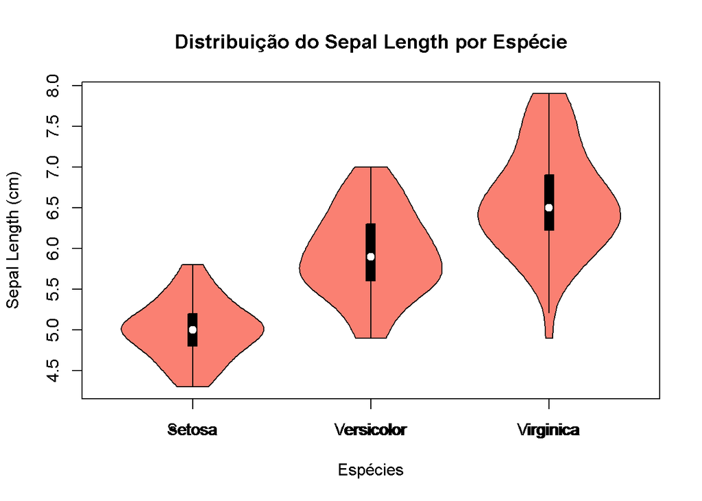

```r
library(vioplot)

# Criar um único gráfico de exemplo mais elaborado
vioplot(Sepal.Length ~ Species, data = iris,
        col = "salmon",
        xlab = "Espécies", ylab = "Sepal Length (cm)",
        main = "Distribuição do Sepal Length por Espécie")

# Remover números do eixo x e adicionar labels personalizadas
axis(1, at = 1:3, labels = c("Setosa", "Versicolor", "Virginica"))
```

```r
variaveis <- c("Sepal.Length", "Sepal.Width", "Petal.Length", "Petal.Width")
nomes <- c("Sepal Length", "Sepal Width", "Petal Length", "Petal Width")

# Exercício completo: Boxplots com apply vs estruturas de controle

# 1. Abordagem com família apply
cat("=== MÉTODO APPLY ===\n")
```

```
## === MÉTODO APPLY ===
```

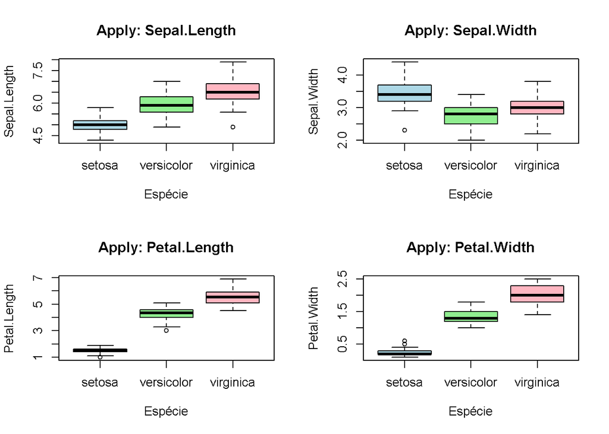

```r
par(mfrow = c(2, 2))
tempo_apply <- system.time({
  lapply(names(iris)[1:4], function(var) {
    boxplot(iris[[var]] ~ iris$Species,
            main = paste("Apply:", var),
            xlab = "Espécie",
            ylab = var,
            col = c("lightblue", "lightgreen", "lightpink"))
  })
})
```

```r
par(mfrow = c(1, 1))

# 2. Abordagem com for loop
cat("=== MÉTODO FOR LOOP ===\n")
```

```
## === MÉTODO FOR LOOP ===
```

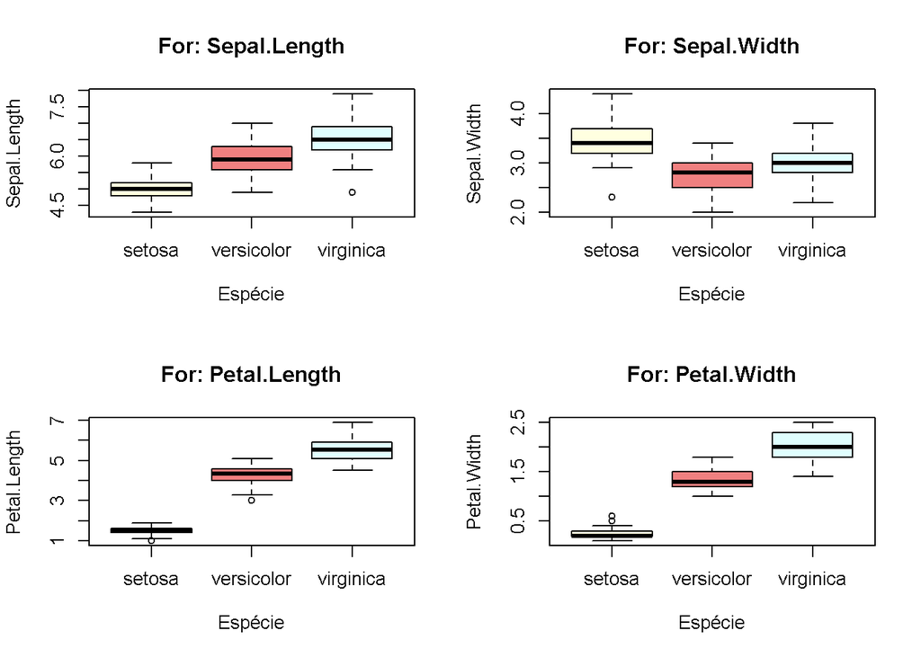

```r
par(mfrow = c(2, 2))
tempo_for <- system.time({
  for (var in names(iris)[1:4]) {
    boxplot(iris[[var]] ~ iris$Species,
            main = paste("For:", var),
            xlab = "Espécie",
            ylab = var,
            col = c("lightyellow", "lightcoral", "lightcyan"))
  }
})
```

```r
par(mfrow = c(1, 1))

# 3. Comparação de tempos
cat("=== COMPARAÇÃO DE TEMPOS ===\n")
```

```
## === COMPARAÇÃO DE TEMPOS ===
```

```r
resultados <- data.frame(
  Método = c("apply", "for loop"),
  Tempo_usuário = c(tempo_apply[1], tempo_for[1]),
  Tempo_sistema = c(tempo_apply[2], tempo_for[2]),
  Tempo_total = c(tempo_apply[3], tempo_for[3])
)

print(resultados)
```

```
##     Método Tempo_usuário Tempo_sistema Tempo_total
## 1    apply          0.02             0        0.01
## 2 for loop          0.03             0        0.03
```

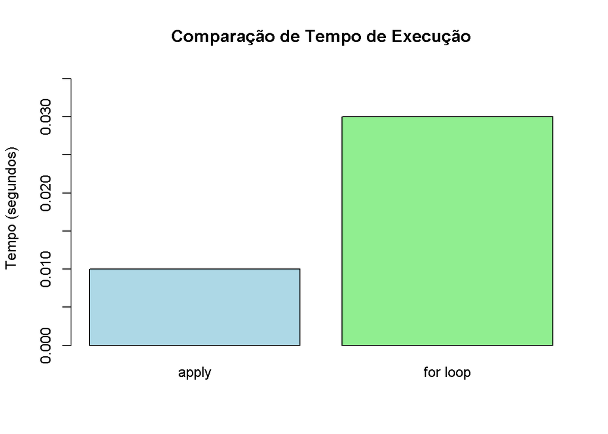

```r
# 4. Gráfico comparativo
barplot(resultados$Tempo_total,
        names.arg = resultados$Método,
        main = "Comparação de Tempo de Execução",
        ylab = "Tempo (segundos)",
        col = c("lightblue", "lightgreen"),
        ylim = c(0, max(resultados$Tempo_total) * 1.2))
```

```r
# 5. Conclusão
cat("\n=== CONCLUSÃO ===\n")
```

```
##
## === CONCLUSÃO ===
```

```r
if (resultados$Tempo_total[1] < resultados$Tempo_total[2]) {
  cat("apply foi mais rápido\n")
} else if (resultados$Tempo_total[1] > resultados$Tempo_total[2]) {
  cat("for loop foi mais rápido\n")
} else {
  cat("Os tempos são iguais\n")
}
```

```
## apply foi mais rápido
```

```r
cat("Diferença:", abs(resultados$Tempo_total[1] - resultados$Tempo_total[2]), "segundos\n")
```

```
## Diferença: 0.02 segundos
```

# Classes de data frames – família apply:

## Descubra qual das variáveis do conjunto de dados iris não é numérica.

```r
# Maneira mais simples de descobrir variáveis não numéricas no iris
sapply(iris, class)
```

```
## Sepal.Length  Sepal.Width Petal.Length  Petal.Width      Species
##    "numeric"    "numeric"    "numeric"    "numeric"     "factor"
```

## Identifique os níveis desse fator (utilize a função level).

```r
levels(iris$Species)
```

```
## [1] "setosa"     "versicolor" "virginica"
```

## Ao invés disso, experimente a função unique e compare a saída.

```r
unique(iris$Species)
```

```
## [1] setosa     versicolor virginica
## Levels: setosa versicolor virginica
```

## Repita o item (a) usando estruturas de controle. Compare o tempo entreas duas abordagens (Estruturas de controle e família apply).

```r
# Exercício completo: Descobrir variáveis não numéricas

# Método 1: Família apply
cat("=== MÉTODO APPLY ===\n")
```

```
## === MÉTODO APPLY ===
```

```r
tempo_apply <- system.time({
  classes_apply <- sapply(iris, class)
  nao_numericas_apply <- which(classes_apply != "numeric")
})
cat("Variáveis não numéricas (apply):", names(nao_numericas_apply), "\n")
```

```
## Variáveis não numéricas (apply): Species
```

```r
# Método 2: For loop
cat("\n=== MÉTODO FOR LOOP ===\n")
```

```
##
## === MÉTODO FOR LOOP ===
```

```r
tempo_for <- system.time({
  nao_numericas_for <- c()
  for (i in 1:ncol(iris)) {
    if (class(iris[[i]]) != "numeric") {
      nao_numericas_for <- c(nao_numericas_for, i)
    }
  }
  names(nao_numericas_for) <- names(iris)[nao_numericas_for]
})
cat("Variáveis não numéricas (for):", names(nao_numericas_for), "\n")
```

```
## Variáveis não numéricas (for): Species
```

```r
# Comparação de tempos
cat("\n=== COMPARAÇÃO DE TEMPOS ===\n")
```

```
##
## === COMPARAÇÃO DE TEMPOS ===
```

```r
resultados <- data.frame(
  Método = c("apply", "for loop"),
  Tempo_total = c(tempo_apply[3], tempo_for[3])
)
print(resultados)
```

```
##     Método Tempo_total
## 1    apply           0
## 2 for loop           0
```

[figure not shown]

```r
# Gráfico comparativo
barplot(resultados$Tempo_total,
        names.arg = resultados$Método,
        main = "Tempo para identificar variáveis não numéricas",
        ylab = "Tempo (segundos)",
        col = c("lightblue", "lightgreen"))
```

```r
# Conclusão
cat("\n=== CONCLUSÃO ===\n")
```

```
##
## === CONCLUSÃO ===
```

```r
if (resultados$Tempo_total[1] < resultados$Tempo_total[2]) {
  cat("apply foi", resultados$Tempo_total[2] - resultados$Tempo_total[1], "segundos mais rápido\n")
} else {
  cat("for loop foi", resultados$Tempo_total[1] - resultados$Tempo_total[2], "segundos mais rápido\n")
}
```

```
## for loop foi 0 segundos mais rápido
```

# Conjunto de dados – diamonds{ggplot2}:

## Quais são as colunas de classe não numérica?

```r
# Carregar o pacote e verificar a estrutura dos dados
library(ggplot2)
str(diamonds)
```

```
## tibble [53,940 × 10] (S3: tbl_df/tbl/data.frame)
##  $ carat  : num [1:53940] 0.23 0.21 0.23 0.29 0.31 0.24 0.24 0.26 0.22 0.23 ...
##  $ cut    : Ord.factor w/ 5 levels "Fair"<"Good"<..: 5 4 2 4 2 3 3 3 1 3 ...
##  $ color  : Ord.factor w/ 7 levels "D"<"E"<"F"<"G"<..: 2 2 2 6 7 7 6 5 2 5 ...
##  $ clarity: Ord.factor w/ 8 levels "I1"<"SI2"<"SI1"<..: 2 3 5 4 2 6 7 3 4 5 ...
##  $ depth  : num [1:53940] 61.5 59.8 56.9 62.4 63.3 62.8 62.3 61.9 65.1 59.4 ...
##  $ table  : num [1:53940] 55 61 65 58 58 57 57 55 61 61 ...
##  $ price  : int [1:53940] 326 326 327 334 335 336 336 337 337 338 ...
##  $ x      : num [1:53940] 3.95 3.89 4.05 4.2 4.34 3.94 3.95 4.07 3.87 4 ...
##  $ y      : num [1:53940] 3.98 3.84 4.07 4.23 4.35 3.96 3.98 4.11 3.78 4.05 ...
##  $ z      : num [1:53940] 2.43 2.31 2.31 2.63 2.75 2.48 2.47 2.53 2.49 2.39 ...
```

```r
class(diamonds)
```

```
## [1] "tbl_df"     "tbl"        "data.frame"
```

```r
# funciona pois data frames são listas de colunas
sapply(X=diamonds,FUN=class)
```

```
## $carat
## [1] "numeric"
##
## $cut
## [1] "ordered" "factor"
##
## $color
## [1] "ordered" "factor"
##
## $clarity
## [1] "ordered" "factor"
##
## $depth
## [1] "numeric"
##
## $table
## [1] "numeric"
##
## $price
## [1] "integer"
##
## $x
## [1] "numeric"
##
## $y
## [1] "numeric"
##
## $z
## [1] "numeric"
```

## Obtenha a média das colunas 8, 9 e 10 das observações 10000 a 11000.

```r
# Selecionar as observações e colunas específicas
dados_selecionados <- diamonds[10000:11000, c(8, 9, 10)]

# Calcular a média de cada coluna
apply(dados_selecionados, 2, mean)
```

```
##        x        y        z
## 6.237852 6.233506 3.851049
```

## Repita (b), arredondando para um dígito.

```r
round(apply(diamonds[10000:11000, c(8, 9, 10)], 2, mean), 1)
```

```
##   x   y   z
## 6.2 6.2 3.9
```

```r
round(apply(diamonds[10000:11000, c(8, 9, 10)], 2, mean), 1)
```

```
##   x   y   z
## 6.2 6.2 3.9
```

## Repita o exercício usando estruturas de controle. Compare o tempo entreas duas abordagens (Estruturas de controle e família apply).

```r
# Medir o tempo
start_time_loop <- Sys.time()

# Selecionar os dados
dados <- diamonds[10000:11000, c(8, 9, 10)]
medias_loop <- numeric(3)

# Calcular médias com loop
for(i in 1:3) {
  medias_loop[i] <- mean(dados[, i])
}

# Arredondar
resultado_loop <- round(medias_loop, 1)
names(resultado_loop) <- c("x", "y", "z")

end_time_loop <- Sys.time()
# Medir o tempo
start_time_apply <- Sys.time()

resultado_apply <- round(apply(diamonds[10000:11000, c(8, 9, 10)], 2, mean), 1)

end_time_apply <- Sys.time()
# Resultados
print("Estruturas de controle:")
```

```
## [1] "Estruturas de controle:"
```

```r
print(resultado_loop)
```

```
##  x  y  z
## NA NA NA
```

```r
print("Família apply:")
```

```
## [1] "Família apply:"
```

```r
print(resultado_apply)
```

```
##   x   y   z
## 6.2 6.2 3.9
```

```r
# Comparação de tempo
tempo_loop <- end_time_loop - start_time_loop
tempo_apply <- end_time_apply - start_time_apply

print(paste("Tempo com loop:", round(tempo_loop, 4), "segundos"))
```

```
## [1] "Tempo com loop: 0.0057 segundos"
```

```r
print(paste("Tempo com apply:", round(tempo_apply, 4), "segundos"))
```

```
## [1] "Tempo com apply: 0.0011 segundos"
```

# Função aggregate – Conjunto de dados – mtcars{datasets}:

## a. Calcule a mediana de cada coluna ordenada pelo número de carburadores.Use os argumentos padrão “x”, “by” e “FUN”.

```r
# Mediana de cada coluna agrupada por carb (carburadores)
resultado_a <- aggregate(x = mtcars[-11],
                        by = list(carb = mtcars$carb),
                        FUN = median)

# Ordenar pelo número de carburadores
resultado_a <- resultado_a[order(resultado_a$carb), ]
print(resultado_a)
```

```
##   carb   mpg cyl   disp  hp  drat    wt   qsec  vs am gear
## 1    1 22.80   4 108.00  93 3.850 2.320 19.470 1.0  1  4.0
## 2    2 22.10   4 143.75 111 3.730 3.170 17.175 0.5  0  4.0
## 3    3 16.40   8 275.80 180 3.070 3.780 17.600 0.0  0  3.0
## 4    4 15.25   8 350.50 210 3.815 3.505 17.220 0.0  0  3.5
## 5    6 19.70   6 145.00 175 3.620 2.770 15.500 0.0  1  5.0
## 6    8 15.00   8 301.00 335 3.540 3.570 14.600 0.0  1  5.0
```

## Aggregate com notação formula

```r
# Usando notação formula
resultado_b <- aggregate(. ~ carb,
                        data = mtcars,
                        FUN = median)

# Ordenar pelo número de carburadores
resultado_b <- resultado_b[order(resultado_b$carb), ]
print(resultado_b)
```

```
##   carb   mpg cyl   disp  hp  drat    wt   qsec  vs am gear
## 1    1 22.80   4 108.00  93 3.850 2.320 19.470 1.0  1  4.0
## 2    2 22.10   4 143.75 111 3.730 3.170 17.175 0.5  0  4.0
## 3    3 16.40   8 275.80 180 3.070 3.780 17.600 0.0  0  3.0
## 4    4 15.25   8 350.50 210 3.815 3.505 17.220 0.0  0  3.5
## 5    6 19.70   6 145.00 175 3.620 2.770 15.500 0.0  1  5.0
## 6    8 15.00   8 301.00 335 3.540 3.570 14.600 0.0  1  5.0
```

## Comparação: Estruturas de controle vs apply

```r
start_time_loop <- Sys.time()

# Obter grupos únicos de carburadores
grupos <- sort(unique(mtcars$carb))
# Criar data frame para resultados
resultado_loop <- data.frame(carb = grupos)

# Para cada coluna (exceto carb)
for(col in names(mtcars)[-11]) {
  col_medias <- numeric(length(grupos))

  for(i in seq_along(grupos)) {
    col_medias[i] <- median(mtcars[mtcars$carb == grupos[i], col])
  }

  resultado_loop[[col]] <- col_medias
}

end_time_loop <- Sys.time()
start_time_agg <- Sys.time()

resultado_agg <- aggregate(. ~ carb, data = mtcars, FUN = median)
resultado_agg <- resultado_agg[order(resultado_agg$carb), ]

end_time_agg <- Sys.time()
# Tempos
tempo_loop <- end_time_loop - start_time_loop
tempo_agg <- end_time_agg - start_time_agg

print("Tempos de execução:")
```

```
## [1] "Tempos de execução:"
```

```r
print(paste("Loop:", round(tempo_loop, 4), "segundos"))
```

```
## [1] "Loop: 0.0085 segundos"
```

```r
print(paste("Aggregate:", round(tempo_agg, 4), "segundos"))
```

```
## [1] "Aggregate: 0.0209 segundos"
```

```r
# Verificar se resultados são iguais
print("Resultados são iguais?")
```

```
## [1] "Resultados são iguais?"
```

```r
print(identical(resultado_loop, resultado_agg))
```

```
## [1] TRUE
```

# 10. A função system.time retorna o tempo de operações em R. Verifique comoesse comando funciona. Para uma matriz X, 107 × 2 e um vetor y de comprimento107, calcule (algumas quantas vezes) o produto Xty, usando multiplicação dematrizes e a função crossproduct. Qual é o procedimento mais rápido?

```r
# Criar dados de exemplo
set.seed(123)
n <- 10^7  # 10 milhões de observações

# Matriz X: 10^7 x 2
X <- matrix(rnorm(2 * n), ncol = 2)

# Vetor y: comprimento 10^7
y <- rnorm(n)

# Método 1: Multiplicação de matrizes tradicional
tempo_tradicional <- system.time({
  resultado_trad <- t(X) %*% y
})

# Método 2: Função crossprod
tempo_crossprod <- system.time({
  resultado_cross <- crossprod(X, y)
})

# Comparar resultados
print("Tempo - Multiplicação tradicional:")
```

```
## [1] "Tempo - Multiplicação tradicional:"
```

```r
print(tempo_tradicional)
```

```
##   usuário   sistema decorrido
##      0.08      0.03      0.11
```

```r
print("Tempo - Crossprod:")
```

```
## [1] "Tempo - Crossprod:"
```

```r
print(tempo_crossprod)
```

```
##   usuário   sistema decorrido
##      0.04      0.00      0.03
```

```r
# Verificar se resultados são iguais
print("Resultados são iguais?")
```

```
## [1] "Resultados são iguais?"
```

```r
print(all.equal(as.numeric(resultado_trad), as.numeric(resultado_cross)))
```

```
## [1] TRUE
```

```r
# Executar múltiplas vezes para obter média
repeticoes <- 10
tempos_trad <- numeric(repeticoes)
tempos_cross <- numeric(repeticoes)

for(i in 1:repeticoes) {
  tempos_trad[i] <- system.time({ t(X) %*% y })["elapsed"]
  tempos_cross[i] <- system.time({ crossprod(X, y) })["elapsed"]
}

# Resultados médios
print(paste("Tempo médio tradicional:", round(mean(tempos_trad), 4), "s"))
```

```
## [1] "Tempo médio tradicional: 0.103 s"
```

```r
print(paste("Tempo médio crossprod:", round(mean(tempos_cross), 4), "s"))
```

```
## [1] "Tempo médio crossprod: 0.048 s"
```

```r
print(paste("Crossprod é", round(mean(tempos_trad)/mean(tempos_cross), 2), "vezes mais rápido"))
```

```
## [1] "Crossprod é 2.15 vezes mais rápido"
```